# Customer churn

Pawel Piela

2020-08-02

1. *Telecom companies are very interested in when customers leave their company (this is called churn). A dataset made publicly available by IBM on customer churn from a telecom company is available in the `BDgraph` **R** package and are called `churn`.*
1. *Construct a Kaplan-Meier estimate of the survival function for time-to-churn and plot the estimate of the survival function.*

The values of a **survival function** $\hat{S}(t)$ can be estimated from:
$$\hat{S}(t_j) = \prod_{k=1}^j \left( 1 - \frac{d_k}{n_k} \right)$$

The calculations can be done using a specified **R** package (e.g. `survival`) or manually.

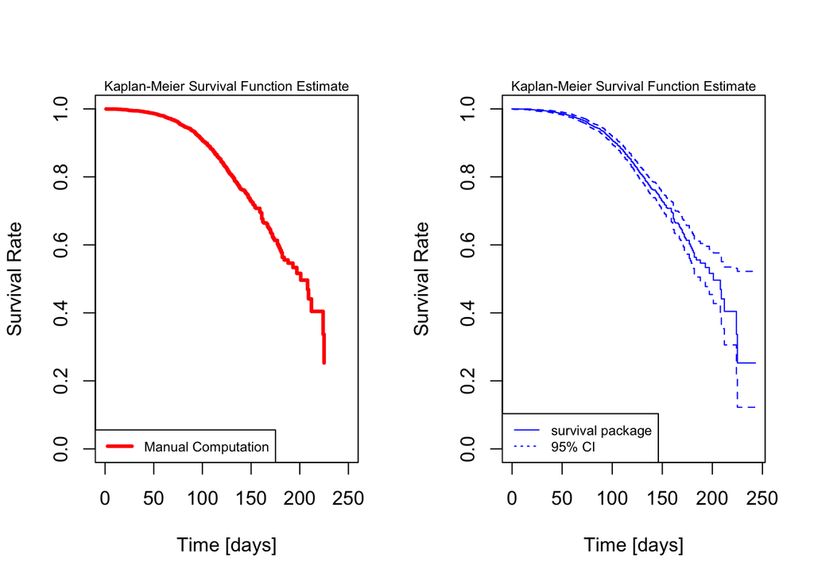

Kaplan-Meier Survival Function Estimates

```r
par(mfrow=c(1, 2))

## Manual Approach
t <- d$Account.Length # time to event
ev <- d$ev            # event

es <- ev[order(t)]
ts <- t[order(t)]

di <- table(ts[es==1])
ni <- sapply(unique(ts[es==1]), function(x) sum(ts>=x))
lambda <- di/ni
S <- cumprod(1-lambda)

plot(as.integer(names(S)), S, type="s", lwd=3, col="red",
     xlab="Time [days]", ylab="Survival Rate",
     ylim=c(0, 1), xlim=c(0, 250))
legend("bottomleft", "Manual Computation", lwd=3, col="red", cex=.7)
mtext("Kaplan-Meier Survival Function Estimate", cex=.7)

## survival package
fit1 <- survfit(Surv(time = d$Account.Length, event=ev)~1)
plot(fit1, lwd=1, col="blue",
     xlab="Time [days]", ylab="Survival Rate")
legend("bottomleft", c("survival package", "95% CI"), lty=c(1, 3),
       col="blue", cex=.7)
mtext("Kaplan-Meier Survival Function Estimate", cex=.7)
```

2. *Estimate the median time-to-churn*

The median time-to-churn is the time when the value of the survival function is equal to `0.5`.

```r
# Manual
median.idx <- which.min(abs(S - 0.5))
print(names(median.idx))
```

```
## [1] "201"
```

```r
# survival package
print(fit1)
```

```
## Call: survfit(formula = Surv(time = d$Account.Length, event = ev) ~
##     1)
##
##       n  events  median 0.95LCL 0.95UCL
##    3333     483     201     188      NA
```

We can get a more accurate result if we fit the model using one of the time-to-event probability density functions, and use the analytical solution to find the median value. To fit the survival model based on the Weibull distribution, we can use the `survival` package, or for educational reasons, we can try to replicate the algorithms manually. To do it, we need to construct the likelihood function where each of the observations contributes in the following ways, under different censoring conditions:

$$l_j = (a+by_j + cy_j^2)\log{f(t_j)} + (d+ey_j + fy_j^2)\log(1-F(t_j))+(g+hy_j+iy_j^2)\log{F(t_j)}$$

The coefficients $a, b, c, d, e, f, g, h, i$ used to select the corresponding term can be calculated by solving:

$$\left[\begin{matrix}
a & b & c \\
d & e & f \\
g & h & i
\end{matrix}\right] \times
\left[\begin{matrix}
0^0 & 1^0 & 2^0 \\
0^1 & 1^1 & 2^1 \\
0^2 & 1^2 & 2^2
\end{matrix}\right]=
\left[\begin{matrix}
1 & 0 & 0 \\
0 & 1 & 0 \\
0 & 0 & 1
\end{matrix}\right]$$

The solution is:

$$\left[\begin{matrix}
a & b & c \\
d & e & f \\
g & h & i
\end{matrix}\right] =
\left[\begin{matrix}
1 & -1.5 & 0.5 \\
0 & 2 & -1 \\
0 & -0.5 & 0.5
\end{matrix}\right]$$

The log likelihood function can be implemented in the following way:

```r
# Log-likelihood
llk <- function(theta) {
  alpha <- theta[1]
  beta <- theta[2]

  # fully observed
  f <- dweibull(t, alpha, beta, log=TRUE)
  # f <- log(alpha) - alpha*log(beta) + (alpha - 1)*log(t) - (t/beta)^alpha

  # right censored
  rc <- log(1 - pweibull(t, alpha, beta, log=FALSE))
  # rc <- -(t/beta)^alpha

  # left censored
  lc <- pweibull(t, alpha, beta, log=TRUE)
  # lc <- log( 1 - exp(-(t/beta)^alpha))

  sum( (1 - 1.5*ev + 0.5*ev^2)*rc + (2*ev-ev^2)*f + (-0.5*ev + 0.5*ev^2)*lc)
}
```

More computationally efficient version written in C++ using the Rcpp library:

```cpp
double llkC(NumericVector theta, NumericVector time, NumericVector event)
{
  NumericVector params = theta;
  NumericVector t = time;
  NumericVector e = event;

  double alpha = params(0);
  double beta = params(1);

  int N = t.size();

  NumericVector f(N);
  NumericVector rc(N);
  NumericVector lc(N);

  NumericVector e_sq(N);
  NumericVector pow_t_beta(N);

  pow_t_beta = pow(t/beta, alpha);
  e_sq = pow(e, 2);

  f = log(alpha) - alpha*log(beta) + (alpha - 1)*log(t) - pow_t_beta;
  rc = -pow_t_beta;
  lc = log(1 - exp(-pow_t_beta));

  double llk = sum((1-1.5*e+0.5*e_sq)*rc + (2*e - e_sq)*f + (-0.5*e + 0.5*e_sq)*lc);

  return(llk);
}
```

The parameter estimates which maximise the log-likelihood of the observed data can be obtained from the `optim` function.

```r
# alpha0 = 1, beta0 = 100
theta0 <- c(1, 100)

#optimise
fit <- optim(theta0, llkC.wrap, method="BFGS", control=list(fnscale=-1), hessian = TRUE)

alpha <- fit$par[1]
beta <- fit$par[2]

# median
m.churn <- beta * (log(2))^(1/alpha)
print(m.churn)
```

```
## [1] 198.6128
```

```r
df.par <- cbind(fit$par, diag(sqrt(-1/fit$hessian)))
colnames(df.par) <- c("MLE", "sd")
rownames(df.par) <- c("$\\hat{\\alpha}$", "$\\hat{\\beta}$")
knitr::kable(df.par, digits=3, caption="Weibull model MLE estimates")
```

Weibull model MLE estimates

|  | MLE | sd |
| --- | --- | --- |
| $\hat{\alpha}$ | 2.811 | 0.065 |
| $\hat{\beta}$ | 226.268 | 3.662 |

The `survival` package includes the `survreg` function, which automates all the calculations. Its results are nearly identical:

```r
sr.fit <- survreg(Surv(t, ev) ~ 1, dis="weibull")
sr.vec <- c(1/sr.fit$scale, exp(sr.fit$coefficients))
names(sr.vec) <- c("alpha", "beta")
sr.vec
```

```
##      alpha       beta
##   2.811443 226.268415
```

Once we know the shape and rate parameters of the Weibull distribution, we can calculate the median from the closed-form equation:

$$\text{median} = \beta \log(2)^{1/\alpha} \approx \hat{\beta} \log(2)^{1/\hat{\alpha}} = 198.6128$$

3. *Use the Cox proportianal hazards method to study the impact of the customer covariates on the time-to-churn and develop a parsimonious model.*

The dataset contains 19 covariates. Three of them are factorised, and the rest are numerical. One of the factorised covariates (`State`) has 51 levels and can be removed if we consider the national scope. Let $x_i = (x_{i1}, x_{i2}, \ldots, x_{i18})$ be the vector of covariates recorded for survival time $t_i$. Then, the Cox Proportional Hazards Model defines the hazard function for the i<sup>th</sup> observation as:

$$\lambda(t_j|x_i) = \lambda_0(t) exp \left( \sum_{j=1}^{18}\beta_j x_{ij}\right)$$
where $\beta$ is a vector or regression parameters.

Function `coxph` from the `survival` package allows us to check, which covariates have a statistically significant effect on the hazard.

```r
cx <- coxph(Surv(time=Account.Length, event=ev) ~ . - State - Churn, data=d)
summary(cx, conf.int=FALSE)
```

```
## Call:
## coxph(formula = Surv(time = Account.Length, event = ev) ~ . -
##     State - Churn, data = d)
##
##   n= 3333, number of events= 483
##
##                      coef  exp(coef)   se(coef)      z Pr(>|z|)
## Area.Code       4.256e-04  1.000e+00  1.077e-03  0.395 0.692768
## Int.l.Planyes   1.201e+00  3.323e+00  1.038e-01 11.573  < 2e-16 ***
## VMail.Planyes  -2.142e+00  1.174e-01  4.845e-01 -4.421 9.81e-06 ***
## VMail.Message   4.356e-02  1.045e+00  1.495e-02  2.914 0.003572 **
## Day.Mins       -9.006e-01  4.063e-01  2.667e+00 -0.338 0.735576
## Day.Calls       1.323e-03  1.001e+00  2.242e-03  0.590 0.555070
## Day.Charge      5.351e+00  2.108e+02  1.569e+01  0.341 0.732999
## Eve.Mins        8.643e-01  2.373e+00  1.344e+00  0.643 0.520337
## Eve.Calls       1.562e-03  1.002e+00  2.342e-03  0.667 0.504804
## Eve.Charge     -1.012e+01  4.035e-05  1.582e+01 -0.640 0.522412
## Night.Mins     -1.230e-02  9.878e-01  7.374e-01 -0.017 0.986693
## Night.Calls     1.335e-03  1.001e+00  2.416e-03  0.552 0.580670
## Night.Charge    3.415e-01  1.407e+00  1.639e+01  0.021 0.983371
## Intl.Mins      -4.326e+00  1.322e-02  4.402e+00 -0.983 0.325763
## Intl.Calls     -7.365e-02  9.290e-01  2.121e-02 -3.473 0.000514 ***
## Intl.Charge     1.622e+01  1.110e+07  1.630e+01  0.995 0.319730
## CustServ.Calls  3.075e-01  1.360e+00  2.745e-02 11.201  < 2e-16 ***
## ---
## Signif. codes:  0 '***' 0.001 '**' 0.01 '*' 0.05 '.' 0.1 ' ' 1
##
## Concordance= 0.772  (se = 0.012 )
## Likelihood ratio test= 443.1  on 17 df,   p=<2e-16
## Wald test            = 468.6  on 17 df,   p=<2e-16
## Score (logrank) test = 498.6  on 17 df,   p=<2e-16
```

The only statistically significant results (at $\alpha=0.05$) are:

Cox Proportional Hazards. Statistically significant covariates.

|  | Description | exp(Coefficient) |
| --- | --- | --- |
| Int.l.Planyes | Categorical, yes or no, international plan. | 3.323 |
| VMail.Planyes | Categorical, yes or no, voice mail plan. | 0.117 |
| VMail.Message | Count, number of voice mail messages. | 1.045 |
| Intl.Calls | Count, total number of international calls. | 0.929 |
| CustServ.Calls | Count, number of calls to customer service. | 1.360 |

The parsimonious model is relying only on those 5 covariates.

```r
fit.pars <- survreg(Surv(time=Account.Length, event=ev) ~
                      Int.l.Plan + VMail.Plan + VMail.Message + Intl.Calls + CustServ.Calls,
                    data=d)
summary(fit.pars)
```

```
##
## Call:
## survreg(formula = Surv(time = Account.Length, event = ev) ~ Int.l.Plan +
##     VMail.Plan + VMail.Message + Intl.Calls + CustServ.Calls,
##     data = d)
##                   Value Std. Error      z       p
## (Intercept)     5.55418    0.04889 113.61 < 2e-16
## Int.l.Planyes  -0.44955    0.03952 -11.38 < 2e-16
## VMail.Planyes   0.63196    0.16890   3.74 0.00018
## VMail.Message  -0.01287    0.00524  -2.45 0.01411
## Intl.Calls      0.02264    0.00742   3.05 0.00227
## CustServ.Calls -0.10816    0.01045 -10.35 < 2e-16
## Log(scale)     -1.03396    0.03577 -28.91 < 2e-16
##
## Scale= 0.356
##
## Weibull distribution
## Loglik(model)= -3244   Loglik(intercept only)= -3383.9
##  Chisq= 279.77 on 5 degrees of freedom, p= 2.2e-58
## Number of Newton-Raphson Iterations: 8
## n= 3333
```

The baseline Weibull parameters of the parsimonious model are slightly different from the full model.

```r
pars.vec <- c(1/fit.pars$scale, exp(fit.pars$coefficients[1]))
names(pars.vec) <- c("alpha", "beta")
pars.vec
```

```
##      alpha       beta
##   2.812171 258.314657
```

Exponentiated coefficients either increase the hazard (if they are $>1$) or decrease it (if they are $<1$).

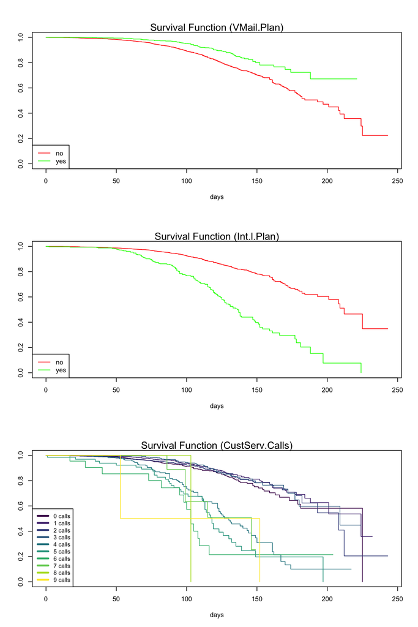

4. *Summarize the results of your analysis*

The median time-to-churn is **201 days**. This period is slightly larger than 6 months (182 days). Considering the fact that most of the mobile network operators offer 12 or 24 months contract, it could mean that half of the customers will leave before it ends.

### A phone I cannot afford

There are *5* covariates that can be used in the parsimonious model. **International Plan** increases the hazard of the customer leaving three-fold. It is an interesting observation because people who make more **International Calls** are more likely to stay longer. One explanation of this paradox may be that some customers go for more expensive plans (which include international calls), to get better phones for less. Later, they are either unable or unwilling to pay, and the contract is terminated more quickly.

The fact may partially support this hypothesis, that similar thing is happening with **Voice Mail Plan** and **Voice Mail Message**. Even though customers who have the voice mail plan activated are 88.3% less likely to go at any time, every message left in their voice mail increases the hazard by 4.5%. Voice mail is targeted towards people, who cannot answer the phone calls at any given moment, probably because they are busy making money. If a customer has many voice mail messages, it could mean that they have either shared the number with someone they would like to avoid, or they never intended to use that number. In the latter case, messages are most likely left by the debt collectors.

### Four times a charm

```r
d$cs <- d$CustServ.Calls > 4
coxph(Surv(t, ev) ~ d$cs)
```

```
## Call:
## coxph(formula = Surv(t, ev) ~ d$cs)
##
##            coef exp(coef) se(coef)     z      p
## d$csTRUE 1.6135    5.0205   0.1365 11.82 <2e-16
##
## Likelihood ratio test=95.03  on 1 df, p=< 2.2e-16
## n= 3333, number of events= 483
```